# Periodo frazionario

Bozza

2023-08-17

# Periodo frazionario

## Scopo del progetto

Lo scopo di questo progetto è implementare due algoritmi per il calcolo del *periodo frazionario minimo* di una stringa e misurarne i tempi medi di esecuzione. Per *periodo frazionario minimo* si intende, data una stringa *S*, la lunghezza (*p*) della sottostringa più breve che può essere ripetuta in modo da formare la stringa *S*. Deve quindi soddisfare la seguente proprietà:

$$s(i)=s(i+p) \quad \forall i= 1, \dots ,
n-p$$

- $s$: stringa
- $p$: lunghezza del periodo
- $n$: lunghezza della stringa
- $i$: parte esterna al periodo frazionario

## Algoritmi e fondamenti teorici

### PeriodNaive

*PeriodNaive* è un algoritmo di complessità $O(n^2)$ che, mediante un ciclo *for*, itera su di una stringa, e ne analizza ogni possibile periodo. Partendo da un periodo di lunghezza *p=1* e incrementando di uno ogni volta il valore, la stringa viene suddivisa in due parti: *head* e *tail*. Quando queste coincidono l’esecuzione termina e viene restituita la lunghezza finale *p*.

```
Funzione periodoNaive(Stringa):
    Length= lunghezza(Stringa)
    ITERA P da 1 fino Length{
        Head= sottostringa(Stringa, 0 -> Length-P )
        Hail= sottostringa(Stringa, P -> Length)

        SE Head è uguale a Tail:
            RESTITUISCI P
    }
```

#### Calcolo di complessità

| Codice | Costo | Volte |
| --- | --- | --- |
| `public static int periodNaive(String stringa) {` |  |  |
| `int n= stringa.length();` | $O(1)$ | 1 |
| `for (int p=1; p<=n;p++){` |  |  |
| `String head=stringa.substring(0, n-p);` | $O(n)$ | n |
| `String tail=stringa.substring(p, n);` | $O(n)$ | n |
| `if (head.equals(tail)){` | $O(p)$ | n |
| `return p;` | $O(1)$ | 1 |
| `}` |  |  |
| `}` |  |  |
| `return ERR;` |  |  |
| `}` |  |  |

Dalla tabella risulta che il costo computazionale dell’algoritmo è:

$$\begin {aligned}
Costo &= O(1) + O(n) \cdot n + O(n) \cdot n +O(p) \cdot n +O(1)\\
&=n \cdot ( 2 \cdot O(n) +O(p) ) + 2 \cdot O(1)\\
&\simeq O(n^2)
\end {aligned}$$

### PeriodSmart

*PeriodSmart* è un algoritmo di complessità $O(n)$ che utilizza il concetto di *bordo* per calcolare la lunghezza del *periodo frazionario minimo*. Genera un *array* per memorizzare la lunghezza dei bordi delle sottostringhe (`r[i]` è il bordo della sottostringa che termina in posizione `i - 1`) e poi *itera* sulla stringa cercando per ogni carattere un bordo fra i caratteri precedenti. Se il carattere corrente coincide col bordo, incrementa la lunghezza del bordo, altrimenti la riduce cercando un bordo più corto. Il periodo frazionario minimo è dato dalla lunghezza della stringa meno la lunghezza massima del bordo.

```
Funzione periodSmart(S: stringa):
    N = lunghezza(s)
    R = array di interi di dimensione n + 1
    R[1] = 0
    ITERA I da 2 fino a N:
        J = R[I - 1]
        FINCHE  J > 0,
                carattere in (i - 1) di S != dal carattere in posizione J di S:
            J = R[J]
        SE carattere in (I - 1) di S == al carattere in J di s:
            R[I] = J + 1
        ALTRIMENTI:
            R[I] = 0
    MaxBordo = R[N]
    PeriodoFrazionario = N - MaxBordo
    RESTITUISCI PeriodoFrazionario
```

#### Calcolo di complessità

| Codice | Costo | Volte |
| --- | --- | --- |
| `public static int periodSmart(String s) {` |  |  |
| `int n = s.length();` | $O(1)$ | 1 |
| `int[] r = new int[n + 1];` | $O(1)$ | 1 |
| `r[1] = 0;` | $O(1)$ | 1 |
| `for (int i = 2; i <= n; i++) {` |  |  |
| `int j = r[i - 1];` | $O(1)$ | n |
| `while (j > 0 && s.charAt(i - 1) != s.charAt(j)) {` | $O(2)$ | n |
| `j = r[j];` | $O(1)$ | n |
| `}` |  |  |
| `if (s.charAt(i - 1) == s.charAt(j)) {` | $O(1)$ | n |
| `r[i] = j + 1;` | $O(1)$ | n |
| `} else {` |  |  |
| `r[i] = 0;` | $O(1)$ | n |
| `}}` |  |  |
| `int maxBordo = r[n];` | $O(1)$ | 1 |
| `int periodoFrazionario = n - maxBordo;` | $O(1)$ | 1 |
| `return periodoFrazionario;` | $O(1)$ | 1 |
| `}` |  |  |

Dalla tabella risulta che il costo computazionale dell’algoritmo è:

$$\begin {aligned}
Costo &= O(1) + O(1) + O(1) + O(1) \cdot n + O(2) \cdot n + O(1)
\cdot n + O(1) \cdot n + O(1) \cdot n + O(1) \cdot n + O(1) + O(1) +
O(1) \\
&= 6 \cdot O(1) + n \cdot O(1) + O(2)\\
&\simeq O(n)
\end {aligned}$$

## Analisi delle prestazioni

Per valutare le prestazioni degli algoritmi in maniera empirica si è deciso di realizzare un programma Java in grado di misurare i tempi medi di esecuzione degli algoritmi. Il progetto si suddivide in 5 classi:

- **Progetto**: classe principale che contiene i passaggi per testare, cronometrare e ricavare dati utili in fase di analisi.
- **Algos**: contiene l’implementazione degli algoritmi per il calcolo del periodo frazionario minimo di una stringa.
- **Chrono**: fornisce meccanismi di cronometraggio necessari per misurare il tempo di esecuzione del programma e la stima di risoluzione del clock di sistema in nanosecondi.
- **Logger**: gestisce la registrazione delle informazioni rilevanti su un file .csv.
- **StringGenerator**: genera stringhe casuali con varie lunghezze comprese fra 1000 e 500000. Queste hanno una distribuzione esponenziale e sono basate su un alfabeto ternario: *a*, *b*, *c*.

### Metodologia di test

Una volta calcolato il *tempo minimo misurabile*, per ricavare dati attendibili sono state eseguite 6 run da 100 iterazioni ciascuna. Ad ogni iterazione una stringa generata casualmente, e progressivamente sempre più lunga, è stata fornita in input ad entrambi gli algoritmi. È stato utilizzato un ciclo *while* per iterare l’esecuzione dell’algoritmo e misurare il tempo trascorso, fino a quando tale tempo non è risultato superiore al *tempo minimo misurabile*. Il *tempo medio di esecuzione* per una singola istanza di input è stato calcolato come il rapporto fra il tempo trascorso e il numero di iterazioni “*while*” eseguite.

```
Progetto main():
    t_min= tempo_minimo_misurabile()
    ITERA Run da 1 a 5{
        ITERA Tedt da 0 a 99{
            stringa= generatringa()
            //testa algoritmo 1
            iterazione= 0
            start= now()
            FAI{
                algoritmo(stringa)
                end= now()
                iterazione++
            }FINCHÈ (end-start< tmin)
            tempo_medio= (end-start)/i
            // testa algoritmo 2
            ...
        }
    }
```

### Risultati sperimentali di vari test

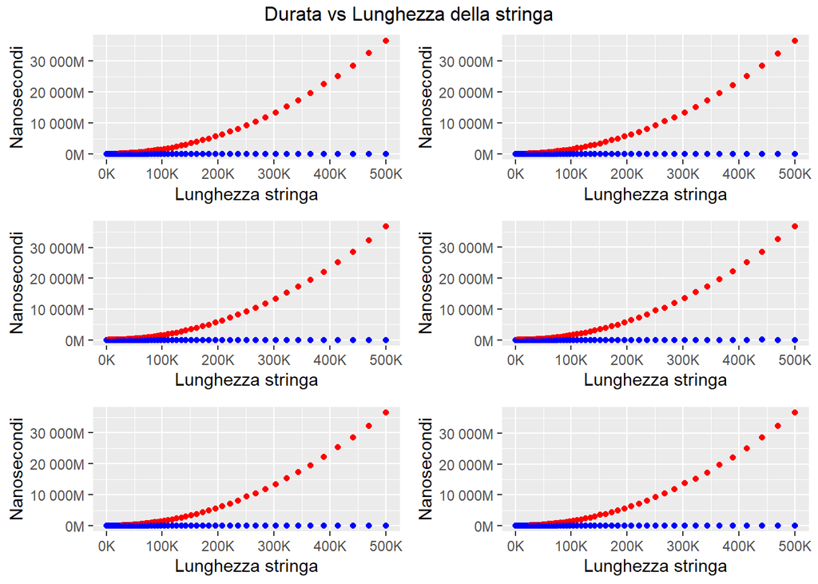

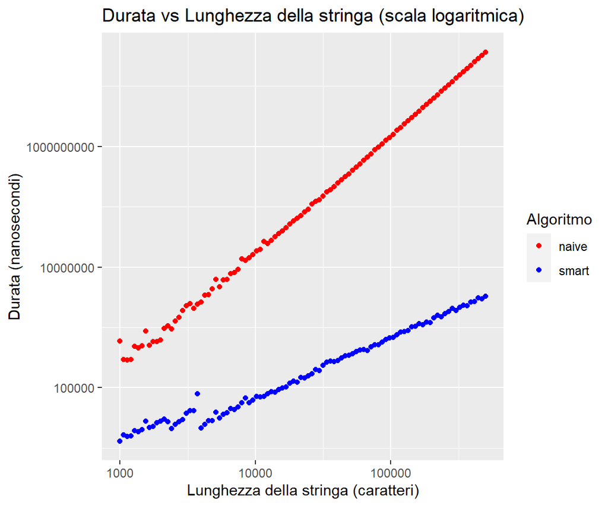

Basandosi sui dati raccolti, è possibile creare un modello in grado di prevedere l’andamento temporale dei due algoritmi. In particolare l’evoluzione del modello Naive può essere descritta da un’equazione di secondo grado:

$$y_{naive} = 565335.910 + 142.414 \cdot x + 0.146 \cdot x^2$$

La validità del modello è supportata dagli indici statistici, in particolare il *Residual Standard Error* indica come l’errore standard dei residui sia di circa 13.73 millisecondi. Gli indici *Multiple R-squared* e *Adjusted R-squared*, atti a spiegare la variabilità dei dati,hanno totalizzato il valore massimo di 1. Infine il *p-value* è di gran lunga inferiore alla soglia di 0.05 ($2,2 \times 10^{-16}$), il che indica un risultato statisticamente significativo.

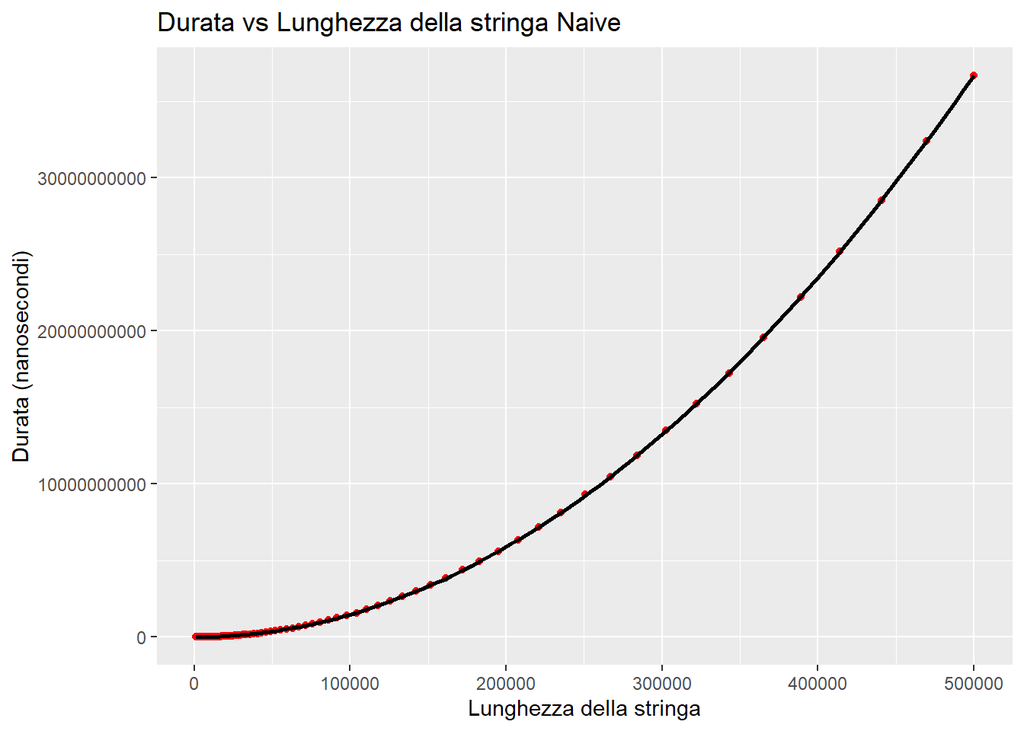

L’evoluzione del modello Smart può essere, invece, descritta da un’equazione di primo grado:
$$y_{smart} = 10679.087 + 6.607 \cdot x$$

Anche in questo caso la validità del modello è supportata dagli indici statistici, in particolare il *Residual Standard Error* indica come l’errore standard dei residui sia di circa 0,0448 millisecondi. Gli indici *Multiple R-squared* e *Adjusted R-squared*,hanno totalizzato il valore quasi massimo di 0.9969. Infine il *p-value* è di gran lunga inferiore alla soglia di 0.05 ($2,2 \times 10^{-16}$), il che indica un risultato statisticamente significativo.

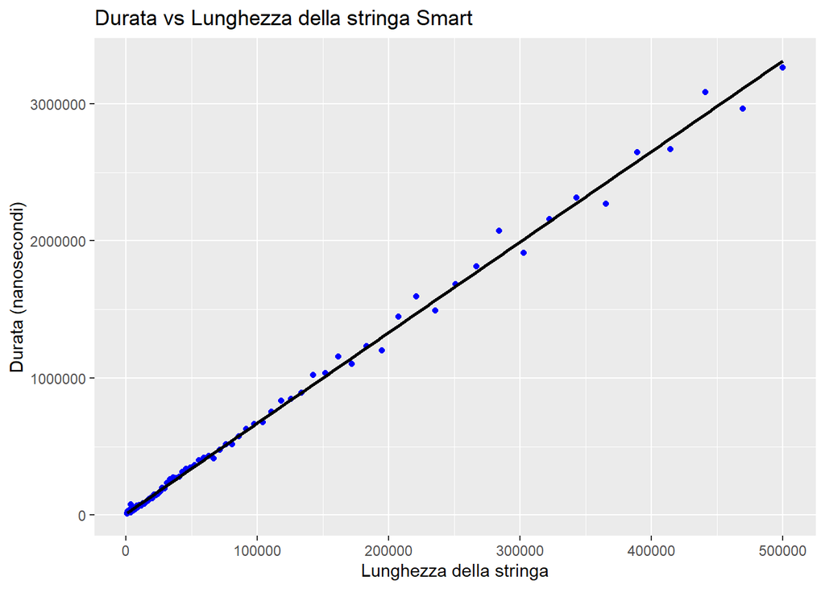